# Paper_1_Final

## Rakesh Senthilvelan and Shin Ehara

## Introduction

When it comes to lending, there have always been disparities between different groups of people in terms of acceptance and accessibility. There have been numerous ways in which discrimination has been employed throughout the years, with lending being one of the largest areas. We wanted to examine the disparities that exist between groups based on race, gender, and sexual orientation among others. The reason we came to these disparities was based on reading previous works done through research institutions such as Vanderbilt University, Proceedings of the National Academy of Sciences of the United States of America, and the National Community Reinvestment Coalition. We wanted to see the specificities of these disparities in terms of how they are carried out in the real world, whether certain other inequities have a domino effect towards lending data, and what potential solutions there may be to this disparity. To look into this, we took in data from the HMDA, short for the Home Mortgage Disclosure Act, which will show data on loan applications for houses (Consumer Finance Protection Bureau). We will be able to see many factors such as race, gender of applicant and co-applicant, income bracket, reason for loan denial, and more. Throughout the research project, we will dive into different areas of discrimination or bias seen in lending data provided by the HMDA in 2017, finding the reasons behind them, and looking into potential areas that will need to be addressed by lenders in the future for a more equitbale experience for everybody.

## Justification for the Data in Approaching the Problem at Hand

The data provided by HMDA dataset provides a lot of insight into the inequities that are present in loans. The data in question is the most recently available set to us, which is 2017. In the preliminary exploratory data analysis, we looked into application status based on race. What we found in this step was interesting. In terms of application status based on race, we noticed significant discrepancies for loan approvals by race, with White and Asian applicants seeing approval ratings around 58%, Hawaiian Native and Pacfic Islander applicants around 51%, and Native American and Black applicants around 44-45%. This shows a significant gap in loan approval ratings between racial groups and this is something we look to further examine in our paper. We believe this will be an interesting area to further examine in the final paper. Based on our EDA, we found numerous statistical differences in the loan data that would potentially point to inequities in this system of America. As a result, this dataset is a strong source to examine the problem at hand and examine the specificities of this inequity in our society.

## Where Does the Data Have Shortcomings?

The data is limited in a few ways. The first is that this is limited to mortgage data from 2017, which limits the amount of overall lending data that is done in the country. Generally, there are many cases where people in this country would not or can not become home buyers. Looking into other, more accesible forms of loans such as car loans would have also been useful in studying the deeper parts of inequity in lending. In addition, there are many cases where the data in this set has missing or undisclosed values for race data. While there are still significant portions of the data that are labeled, there are a lot that have significant statistics attached to them but with race being disclosed as "Information not disclosed by applicant in mail, Internet, or telephone application" or "Not applicable". In the scope of our project, these data points are lost as we cannot decipher their meaning in relation to the inequity we are trying to spotlight.

## The Context of the Inequity

The financial inequities faced by minority populations is not a new concept. According to a report done in 1996 by the Federal Reserve Bank of Boston, it was found that there existed a discrepancy where, when it came to mortgage applications, "minority applicants with the same economic and property characteristics as white applicants would experience a denial rate of 17 percent rather than the actual white denial rate of 11 percent" (Munnell, Browne, et al.). To further understand this discepancy, we must look into concepts of equality. From an egalitarian perspective, this shows a significant discrepancy, with a look into the comparative nature of the above statement showing that there is not equal access to the opportunity of receiving a mortgage (Scanlon, pp. 6-8). From a Rawlisian perspective, this discrepancy does not entitle everybody from the same financial background to the same liberties and opportunities in purchasing a house (Scanlon, pp. 12). This shows that when looking at this research from multiple perspectives of equality, they universally conclude that there is inequality in this situation. However, this was in 1996, that brings forward the question. Has this inequity gotten better since then? In a study from Professor Mark Cohen of Vanderbilt University in July of 2020, it was found that "African Americans pay twice the markup whites did" (Jung & Cohen). This indicates that inequality still exists in the lending industry against minority groups when it comes to loan rejection rates and markups on properties.

## Hypothesis

Based on our preliminary exploratory data analysis and the historical context of this issue, we have the alternative hypothesis that when it comes to mortgage lending that there are significant discrepancies between different racial groups when it comes to loan approval in similar income and loan amount brackets. Our null hypothesis is that there is no significant discrepancy between loan appovals by race within similar income and loan amount brackets.

## Regarding Application Status Based on Race

First, we wanted to look into the application status rates overall based on race. To best do this, we consulted the variables list for the HMDA dataset to effectively understand the meaning of each value under the different variables. From here, we split the dataset into the different racial groups represented in this dataset and ran our analysis on each one.

To get the following statistics, we grouped the dataset by the noted groups in the race category then looked at the percentages of each loan action for each racial group. When looking at the overall rates of rejection for different racial groups, this is what comes up. This shows a significant discrepancy between rejection rates based on race, with the rates for Black and Native American applicants being almost double that of White and Asian applicants.

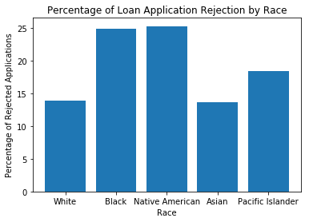

## The Effects of Income on Loan Approval

When we first looked into the exploratory data analysis on application statuses based on raced, we noticed significant disparities between different racial groups in terms of the percentages that were accepted for loans. We first wanted to see if there were other disparities that may have impacted these statistics. The first was to look into income data and see if there are major disparities here that may lead to certain racial groups seeing higher rates of rejection.

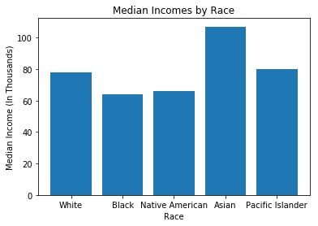

From the above statistics, we can see that the median incomes of each racial group roughly coincides with the acceptance rates on loans. The one discrepancy we see is with Native Hawaiian or other Pacific Islander applicants, which in the case of median show a slightly higher median income compared to White applicants depsite having a 7% lower acceptance rate. We believe that this may be due to a limited sample of this group of applicants in this dataset compared to White applicants, but it is possible that this could point to a significant inequity in this system. The main takeaway was that median incomes show relations to the rates of application acceptance, with White and Asian applicants showing higher rates of loan approvals along with higher median incomes while Black and Native American applicants showed lower median incomes and lower rates of loan approvals.

## A Look Into Median Loan Amounts Taken by Each Group

To look further into this disparity, we wanted to look into the median loan amounts that are seen by these different racial groups. From here, we hope to compare the amounts relative to income and see if there is a significant disparity between different racial groups receiving different results despite having similar financial conditions and loan requests.

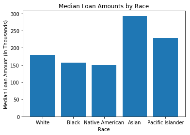

Through this, we can see that the difference between White, Black, and Native American loan amounts is not as significant as the difference in rejection rates or even income.

## The Relationship Between Amount Loaned and Income

To further dive into any disparities in this area, we wanted to look into the relationship between the amount loaned and the income of the people applying for them. To do this, we created a column that took the ratio of loan amount by income, grouped by each racial group, and took the median. We believe that if all these values are similar that there is a sign of inequity in the lending data based on racial groups.

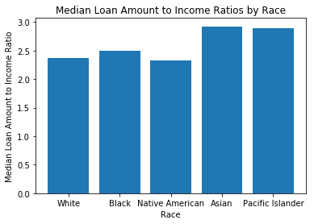

When looking into the factors that developed these ratios, we wanted to rule out other factors that may skew the ratios. We know that some racial groups are more represented than other in this dataset, so we wanted to make sure that the number of loans may skew the averages of these ratios. In order to accomodate this, we used median as our measure to get a value that was more robust to significant outliers and numbers of loans. In terms of comparing loan amounts to incomes, our analysis in the past two charts indicate that the two scale with each other. This would mean that there are not many cases that would result in significant effects in our analysis except for in the case of Asian and Pacific Islander applicants.

## Fairness Quantitative Measures

To see how significant these figures are, we decided to look into these statistics by sampling based on income. We wanted to see if similar income groups and loan amounts had varying outcomes for action taken on the loan when looking at racial group as a factor. For the purpose of this analysis, we will be focusing on the lending experiences faced by Black and White applicants. The fairness of the mortgage lending system will be based on the criteria of group fairness as opposed to individual fairness (Narayanan). We will also do our fairness analysis based on income group to better sample the data during our comparisons. To further make sure our analysis is proper, we will examine the statistics of each analyzed to group to ensure similarities between the distributions of values (Jain, Chiu, and Hawe, pp. 3-8). This will account for any outliers from skewing our results.

For this section, we decided to sample based on the income brackets set by the Federal Income Brackets as of 2020-2021. First, we took into account the range of incomes between 0 and $10,000 yearly. This range has different statistics compared to other ranges as applicants in this range tended to have significantly higher loan-to-income ratios than applicants in other income brackets.

These were the statistics gathered from the White and Black applicants respectively.

|  | applicant_race_1 | applicant_income_000s | loan_amount_000s | action_taken | loan_to_income |
| --- | --- | --- | --- | --- | --- |
| count | 22213.00000 | 22213.00000 | 22210.00000 | 22213.00000 | 22210.00000 |
| mean | 5.00000 | 5.33098 | 130.69671 | 2.86841 | 53.42260 |
| std | 0.00000 | 2.98404 | 158.25087 | 1.28758 | 99.58579 |
| min | 5.00000 | 1.00000 | 1.00000 | 1.00000 | 0.11111 |
| 25% | 5.00000 | 2.00000 | 37.00000 | 3.00000 | 5.75000 |
| 50% | 5.00000 | 6.00000 | 90.00000 | 3.00000 | 19.00000 |
| 75% | 5.00000 | 8.00000 | 177.00000 | 3.00000 | 54.00000 |
| max | 5.00000 | 9.00000 | 5000.00000 | 8.00000 | 2345.00000 |

|  | applicant_race_1 | applicant_income_000s | loan_amount_000s | action_taken | loan_to_income |
| --- | --- | --- | --- | --- | --- |
| count | 4613.00000 | 4613.00000 | 4613.00000 | 4613.00000 | 4613.00000 |
| mean | 3.00000 | 5.56818 | 80.71732 | 3.06850 | 30.01110 |
| std | 0.00000 | 3.01873 | 117.06336 | 1.15405 | 65.13153 |
| min | 3.00000 | 1.00000 | 1.00000 | 1.00000 | 0.11111 |
| 25% | 3.00000 | 3.00000 | 5.00000 | 3.00000 | 1.50000 |
| 50% | 3.00000 | 6.00000 | 48.00000 | 3.00000 | 7.50000 |
| 75% | 3.00000 | 9.00000 | 108.00000 | 3.00000 | 29.20000 |
| max | 3.00000 | 9.00000 | 3000.00000 | 8.00000 | 1240.00000 |

Next, we looked into the income bracket of between 10,000 Dollars and 40,000 Dollars yearly.

These were the statistics gathered from the White and Black applicants respectively.

|  | applicant_race_1 | applicant_income_000s | loan_amount_000s | action_taken | loan_to_income |
| --- | --- | --- | --- | --- | --- |
| count | 1212174.00000 | 1212174.00000 | 1211984.00000 | 1212174.00000 | 1211984.00000 |
| mean | 5.00000 | 29.53894 | 100.05391 | 2.40189 | 3.56404 |
| std | 0.00000 | 7.12961 | 114.95955 | 1.60413 | 6.85167 |
| min | 5.00000 | 10.00000 | 1.00000 | 1.00000 | 0.02564 |
| 25% | 5.00000 | 25.00000 | 58.00000 | 1.00000 | 2.03846 |
| 50% | 5.00000 | 31.00000 | 92.00000 | 2.00000 | 3.19293 |
| 75% | 5.00000 | 35.00000 | 132.00000 | 3.00000 | 4.41379 |
| max | 5.00000 | 39.00000 | 99999.00000 | 8.00000 | 6666.60000 |

|  | applicant_race_1 | applicant_income_000s | loan_amount_000s | action_taken | loan_to_income |
| --- | --- | --- | --- | --- | --- |
| count | 186226.00000 | 186226.00000 | 186220.00000 | 186226.00000 | 186220.00000 |
| mean | 3.00000 | 28.77727 | 88.84596 | 2.75421 | 3.22685 |
| std | 0.00000 | 7.50571 | 66.07497 | 1.55132 | 2.91425 |
| min | 3.00000 | 10.00000 | 1.00000 | 1.00000 | 0.02564 |
| 25% | 3.00000 | 24.00000 | 45.00000 | 1.00000 | 1.62500 |
| 50% | 3.00000 | 30.00000 | 81.00000 | 3.00000 | 2.91176 |
| 75% | 3.00000 | 35.00000 | 124.00000 | 3.00000 | 4.21053 |
| max | 3.00000 | 39.00000 | 2101.00000 | 8.00000 | 122.72727 |

Next, we looked into the bracket between 40,000 and 85,000 US Dollars yearly. This area is of particular interest as it encompasses the median range for most of the population.

These were the statistics gathered from the White and Black applicants respectively.

|  | applicant_race_1 | applicant_income_000s | loan_amount_000s | action_taken | loan_to_income |
| --- | --- | --- | --- | --- | --- |
| count | 3632967.00000 | 3632967.00000 | 3632603.00000 | 3632967.00000 | 3632603.00000 |
| mean | 5.00000 | 60.85646 | 165.66086 | 2.21082 | 2.75741 |
| std | 0.00000 | 12.67135 | 101.51660 | 1.67474 | 1.59241 |
| min | 5.00000 | 40.00000 | 1.00000 | 1.00000 | 0.01190 |
| 25% | 5.00000 | 50.00000 | 104.00000 | 1.00000 | 1.78125 |
| 50% | 5.00000 | 60.00000 | 158.00000 | 1.00000 | 2.68293 |
| 75% | 5.00000 | 72.00000 | 218.00000 | 3.00000 | 3.63636 |
| max | 5.00000 | 84.00000 | 82169.00000 | 8.00000 | 1125.60274 |

|  | applicant_race_1 | applicant_income_000s | loan_amount_000s | action_taken | loan_to_income |
| --- | --- | --- | --- | --- | --- |
| count | 437357.00000 | 437357.00000 | 437349.00000 | 437357.00000 | 437349.00000 |
| mean | 3.00000 | 59.80086 | 160.66249 | 2.49582 | 2.71037 |
| std | 0.00000 | 12.56078 | 93.25648 | 1.67542 | 1.50464 |
| min | 3.00000 | 40.00000 | 1.00000 | 1.00000 | 0.01190 |
| 25% | 3.00000 | 49.00000 | 97.00000 | 1.00000 | 1.68493 |
| 50% | 3.00000 | 59.00000 | 156.00000 | 2.00000 | 2.69863 |
| 75% | 3.00000 | 70.00000 | 216.00000 | 4.00000 | 3.64865 |
| max | 3.00000 | 84.00000 | 3100.00000 | 8.00000 | 60.78431 |

Next, we looked into the income bracket between 85,000 𝑎𝑛𝑑 163,000 US Dollars yearly. We wanted to see how upper middle class brackets would be treated.

These were the statistics gathered from the White and Black applicants respectively.

|  | applicant_race_1 | applicant_income_000s | loan_amount_000s | action_taken | loan_to_income |
| --- | --- | --- | --- | --- | --- |
| count | 2777006.00000 | 2777006.00000 | 2776792.00000 | 2777006.00000 | 2776792.00000 |
| mean | 5.00000 | 114.94448 | 252.05830 | 2.17530 | 2.22105 |
| std | 0.00000 | 21.46654 | 139.77292 | 1.71799 | 1.20148 |
| min | 5.00000 | 85.00000 | 1.00000 | 1.00000 | 0.00617 |
| 25% | 5.00000 | 96.00000 | 157.00000 | 1.00000 | 1.40659 |
| 50% | 5.00000 | 111.00000 | 240.00000 | 1.00000 | 2.13492 |
| 75% | 5.00000 | 131.00000 | 332.00000 | 3.00000 | 2.91489 |
| max | 5.00000 | 162.00000 | 11480.00000 | 8.00000 | 99.82609 |

|  | applicant_race_1 | applicant_income_000s | loan_amount_000s | action_taken | loan_to_income |
| --- | --- | --- | --- | --- | --- |
| count | 232863.00000 | 232863.00000 | 232859.00000 | 232863.00000 | 232859.00000 |
| mean | 3.00000 | 112.17979 | 251.05623 | 2.41466 | 2.26787 |
| std | 0.00000 | 20.77705 | 140.14938 | 1.69816 | 1.24786 |
| min | 3.00000 | 85.00000 | 1.00000 | 1.00000 | 0.00625 |
| 25% | 3.00000 | 95.00000 | 153.00000 | 1.00000 | 1.40566 |
| 50% | 3.00000 | 108.00000 | 245.00000 | 1.00000 | 2.23026 |
| 75% | 3.00000 | 127.00000 | 339.00000 | 4.00000 | 3.03158 |
| max | 3.00000 | 162.00000 | 3705.00000 | 8.00000 | 35.16484 |

Next, we looked into the range of income between $ 163k and 207k. Due to this being a higher income bracket, we wanted to determine if the disparities in lending would be lesser between White and Black applicants in this group.

These were the statistics gathered from the White and Black applicants respectively.

|  | applicant_race_1 | applicant_income_000s | loan_amount_000s | action_taken | loan_to_income |
| --- | --- | --- | --- | --- | --- |
| count | 507945.00000 | 507945.00000 | 507919.00000 | 507945.00000 | 507919.00000 |
| mean | 5.00000 | 182.05368 | 339.86045 | 2.17106 | 1.86966 |
| std | 0.00000 | 12.55346 | 222.92435 | 1.73132 | 1.23096 |
| min | 5.00000 | 163.00000 | 1.00000 | 1.00000 | 0.00488 |
| 25% | 5.00000 | 171.00000 | 202.00000 | 1.00000 | 1.12353 |
| 50% | 5.00000 | 180.00000 | 324.00000 | 1.00000 | 1.78866 |
| 75% | 5.00000 | 192.00000 | 424.00000 | 3.00000 | 2.41916 |
| max | 5.00000 | 206.00000 | 75000.00000 | 8.00000 | 428.57143 |

|  | applicant_race_1 | applicant_income_000s | loan_amount_000s | action_taken | loan_to_income |
| --- | --- | --- | --- | --- | --- |
| count | 29250.00000 | 29250.00000 | 29249.00000 | 29250.00000 | 29249.00000 |
| mean | 3.00000 | 181.40161 | 328.59113 | 2.39395 | 1.81618 |
| std | 0.00000 | 12.43119 | 186.85903 | 1.69307 | 1.03140 |
| min | 3.00000 | 163.00000 | 1.00000 | 1.00000 | 0.00488 |
| 25% | 3.00000 | 170.00000 | 195.00000 | 1.00000 | 1.07222 |
| 50% | 3.00000 | 180.00000 | 326.00000 | 1.00000 | 1.80829 |
| 75% | 3.00000 | 191.00000 | 424.00000 | 4.00000 | 2.41176 |
| max | 3.00000 | 206.00000 | 2800.00000 | 8.00000 | 16.00000 |

Next, we looked into the bracket of 207k to 518k yearly income in US Dollars.

These were the statistics gathered from the White and Black applicants respectively.

|  | applicant_race_1 | applicant_income_000s | loan_amount_000s | action_taken | loan_to_income |
| --- | --- | --- | --- | --- | --- |
| count | 628387.00000 | 628387.00000 | 628361.00000 | 628387.00000 | 628361.00000 |
| mean | 5.00000 | 290.84204 | 473.07298 | 2.12591 | 1.65509 |
| std | 0.00000 | 75.95967 | 341.25748 | 1.69333 | 1.09881 |
| min | 5.00000 | 207.00000 | 1.00000 | 1.00000 | 0.00193 |
| 25% | 5.00000 | 230.00000 | 249.00000 | 1.00000 | 0.87413 |
| 50% | 5.00000 | 266.00000 | 411.00000 | 1.00000 | 1.47500 |
| 75% | 5.00000 | 331.00000 | 613.00000 | 3.00000 | 2.19708 |
| max | 5.00000 | 517.00000 | 19660.00000 | 8.00000 | 67.79310 |

|  | applicant_race_1 | applicant_income_000s | loan_amount_000s | action_taken | loan_to_income |
| --- | --- | --- | --- | --- | --- |
| count | 25800.00000 | 25800.00000 | 25798.00000 | 25800.00000 | 25798.00000 |
| mean | 3.00000 | 276.80264 | 415.80498 | 2.37225 | 1.53538 |
| std | 0.00000 | 68.41849 | 286.95732 | 1.68624 | 0.99127 |
| min | 3.00000 | 207.00000 | 1.00000 | 1.00000 | 0.00208 |
| 25% | 3.00000 | 225.00000 | 217.00000 | 1.00000 | 0.79419 |
| 50% | 3.00000 | 253.00000 | 387.00000 | 1.00000 | 1.45324 |
| 75% | 3.00000 | 306.00000 | 554.75000 | 4.00000 | 2.08333 |
| max | 3.00000 | 517.00000 | 3850.00000 | 8.00000 | 12.66376 |

Finally, we wanted to look into the highest income bracket to see if there were any discrepancies there. For this, we used a bottom bound of $518,000 with no ceiling for the range.

These were the statistics gathered from the White and Black applicants respectively.

|  | applicant_race_1 | applicant_income_000s | loan_amount_000s | action_taken | loan_to_income |
| --- | --- | --- | --- | --- | --- |
| count | 104435.00000 | 104435.00000 | 101199.00000 | 104435.00000 | 101199.00000 |
| mean | 5.00000 | 1572.21562 | 1014.55487 | 2.05030 | 1.10558 |
| std | 0.00000 | 22802.80862 | 3689.20713 | 1.56115 | 1.00444 |
| min | 5.00000 | 518.00000 | 1.00000 | 1.00000 | 0.00000 |
| 25% | 5.00000 | 600.00000 | 348.00000 | 1.00000 | 0.39604 |
| 50% | 5.00000 | 747.00000 | 660.00000 | 1.00000 | 0.80344 |
| 75% | 5.00000 | 1094.00000 | 1250.00000 | 3.00000 | 1.52900 |
| max | 5.00000 | 7073045.00000 | 404000.00000 | 8.00000 | 50.00000 |

|  | applicant_race_1 | applicant_income_000s | loan_amount_000s | action_taken | loan_to_income |
| --- | --- | --- | --- | --- | --- |
| count | 2968.00000 | 2968.00000 | 2903.00000 | 2968.00000 | 2903.00000 |
| mean | 3.00000 | 3129.73518 | 2777.35205 | 2.52392 | 0.82332 |
| std | 0.00000 | 17092.09485 | 21391.07351 | 1.62806 | 0.93197 |
| min | 3.00000 | 518.00000 | 1.00000 | 1.00000 | 0.00026 |
| 25% | 3.00000 | 600.00000 | 174.50000 | 1.00000 | 0.18668 |
| 50% | 3.00000 | 765.00000 | 424.00000 | 3.00000 | 0.48105 |
| 75% | 3.00000 | 1200.00000 | 1000.00000 | 4.00000 | 1.14525 |
| max | 3.00000 | 360000.00000 | 398000.00000 | 8.00000 | 9.96000 |

From the data we gathered, we made two line charts to show the differences in acceptance and denial rates between White and Black applicants in the different incomes brackets. First, we will go with the difference in denial rates.

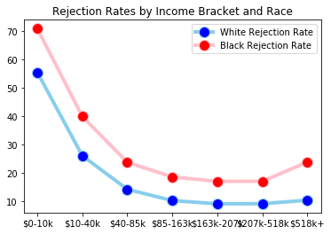

Below, we have graphed the acceptance rates comparison between these two groups by income bracket.

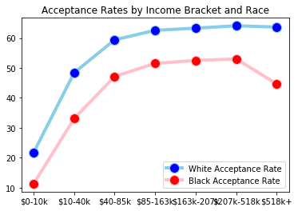

The above charts are indicative of disparities in lending between Black and White applicants. This becomes especially clear when it is shown that the standard deviations of loan-to-income ratios, income, and loan amounts in most brackets is similar between the two despite having significant disparities in acceptance and rejection rates. We believe that this analysis of the acceptance and rejection rates between White and Black applicants is appropriate as it allows us to group by similar income brackets rather than looking at the dataset as a whole. Except for in the highest bracket, this limits significant outliers for income amounts in our analysis. In addition, we were able to compare standard deviations of loan amount and loan-to-income ratios to ensure that the data in these variables were not too differentiated between Black and White applicants. Through this, we were able to appropriately compare these two populations' experiences with lending data and judge the fairness of this system.

## The Cause of the Inequities and Conclusion

To look into the root cause of these inequities, we wanted to look into the history of discrimination in lending pratices. In the 1960s and before, there was a term known as "redlining", which was coined from an action where financial institutions would, quite literally, mark "minority neighborhoods in red" in order to label the people living there as "hazardous" to lenders (Folger). This, in turn, would result in the denial of credit and other financial services to many people who were a part of these minority groups. As a result of the 1968 Fair Housing Act and the 1977 Community Reinvestment Act, the practice of redlining was banned (Brooks, CBS). However, while redlining is now illegal, its effects are still longlasting and visible today. For example, when looking at San Diego, we are able to see that the areas that were once given high, desirable grades in the days of redlining such as coastal La Jolla are still very wealthy and have a White majority population while areas that received lower grades such as Barrio Logan, which tended to have large minority populations, had and continue to face financial hardships (Villafaña & Schroeder). Through this, it can be argued that the main reason for the inequities in lending between White applicants and applicants from minority racial groups is one that is rooted in structural and systemic racism. It is noted that during the 2008 Financial Crisis, there were many cases where "African-Americans with similar credit profiles and down-payment ratios to white borrowers were more likely to receive subprime loans" (Carey). Predatory loan practices against people of minority groups have been happening for a long time and it is evident from our earlier analysis that lending inequities still exist today (Bhutta & Hizmo). Due to the scope of our data, we can only see if loans were accepted or not but we are not able to determine the terms of those loans. It is possible that some the loans we saw in our dataset could have had unfavorable terms for Black applicants when compared to White applicants in the same financial situation. Taking this into consideration, the true nature of this inequity very well could be under represented in the scope of our research as it does not take into account the specificities of the loans given; it only takes into account the status of whether the loan was originated or not.

### Works Cited:

Bhutta, N., & Hizmo, A. (2019). Do Minorities Pay More for Mortgages? SSRN Electronic Journal. Published. https://doi.org/10.2139/ssrn.3352876

Brooks, K. J. (2020, June 12). What is redlining and is it still happening across the U.S. CBS News. https://www.cbsnews.com/news/redlining-what-is-history-mike-bloomberg-comments/

Carey, N. (2010, October 4). Racial predatory loans fueled U.S. housing crisis: study. Reuters. https://www.reuters.com/article/us-usa-foreclosures-race/racial-predatory-loans-fueled-u-s-housing-crisis-study-idUSTRE6930K520101004

Download Historic HMDA Data. (2017). Consumer Financial Protection Bureau. https://www.consumerfinance.gov/data-research/hmda/historic-data/

Folger, J. (2020, November 12). The History of Lending Discrimination. Investopedia. https://www.investopedia.com/the-history-of-lending-discrimination-5076948

Jain, R. K., Chiu, D.-M. W., & Hawe, W. H. (1984, September). A Quantitative Measure Of Fairness And Discrimination For Resource Allocation In Shared Computer Systems. Eastern Research Lab. https://www.cs.wustl.edu/~jain/papers/ftp/fairness.pdf

Jung, J. E., & Cohen, M. (2020, July 20). Racial Disparities in Lending Markets. Vanderbilt Business School. https://business.vanderbilt.edu/news/2020/07/20/racial-disparities-in-lending-markets/

Lopez-Villafaña, A., & Schroeder, L. (2020, September 11). Could you live here? Decades-old redlining still shapes San Diego’s neighborhoods today, advocates say - The. San Diego Union-Tribune. https://www.sandiegouniontribune.com/communities/san-diego/story/2020-09-11/could-you-live-here-decades-old-redlining-still-shapes-san-diegos-neighborhoods-today-advocates-say

Munnell, A. H., Browne, L. E., McEneaney, J., & Tootell, G. M. B. (1992, October 1). Mortgage Lending in Boston: Interpreting HMDA Data. Federal Reserve Bank of Boston. https://www.bostonfed.org/publications/research-department-working-paper/1992/mortgage-lending-in-boston-interpreting-hmda-data.aspx

Narayanan, A. (2018, February 23). 21 fairness definitions and their politics. Fair ML Book. https://fairmlbook.org/tutorial2.html

National Council of Negro Women & National Community Reinvestment Coalition. (2009, June). Assessing the Double Burden: Examining Racial and Gender Disparities in Mortgage Lending. National Community Reinvestment Coalition. https://ncrc.org/wp-content/uploads/2009/07/ncrc%20nosheild%20june%2009.pdf

Scanlon, T. M. (2004, April). When Does Equality Matter? https://law.yale.edu/sites/default/files/documents/pdf/Intellectual_Life/ltw-Scanlon.pdf

Vallentyne, P. (2003). The Demands of Equality: An Introduction. https://klinechair.missouri.edu/docs/vol_2_demands_of_equality.pdf